# ColorAnalysis

Shannon E. Ellis

11/23/2016

Here we will try to:

1. determine what color palletes people like best
2. determine which they find most suitable for which graphs
3. settle the color debate between Jeff and myself

```r
## these data have had duplicates removed
## and emails have been removed
df <- read.csv("Colors.csv", na.strings=c("","NA"))
```

```r
## sex breakdown
table(droplevels(df$sex))
```

```
##
##                                                                Female
##                                                                   198
##                                                                  Male
##                                                                   219
## Nonbinary (& I really appreciate that you included an 'other' option)
##                                                                     1
##                                                     Prefer not to say
##                                                                     7
```

## Palette Preference

Now we’ll look at overall preferences by graph type (not broken down by sex).

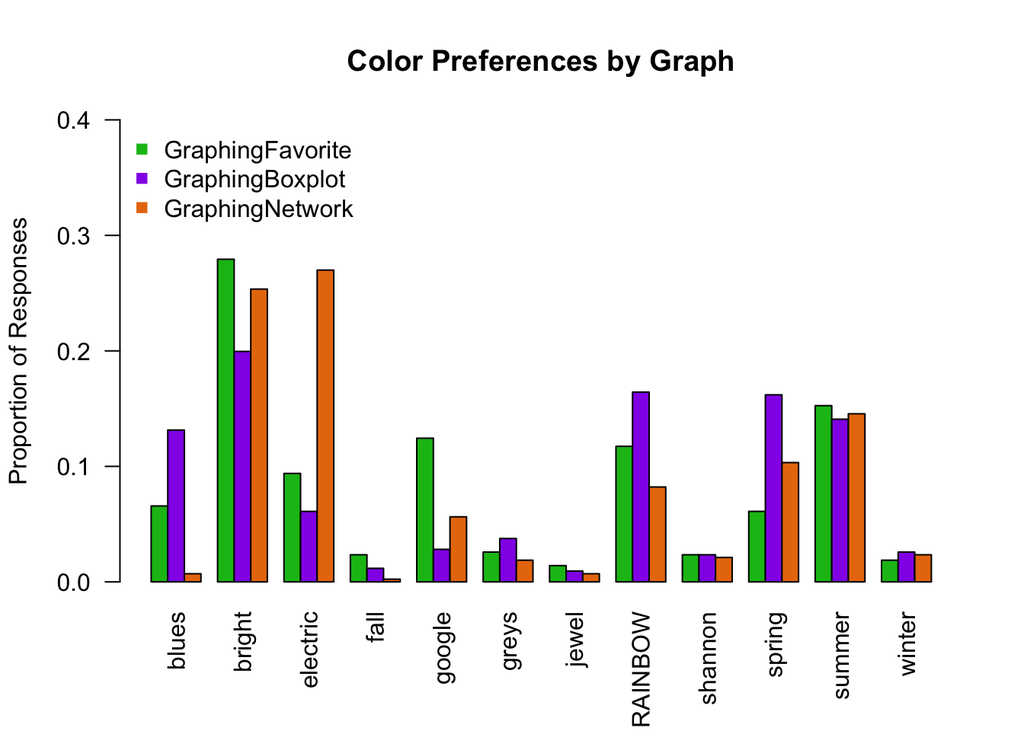

And, what about an individual’s preference from one plot type to another, does that change? Or is their color choice consisitent

```r
## do people make the same choice for graphing a network as they do graphing a boxplot?
table(df[,"GraphingFavorite"]==df[,"GraphingBoxplot"])
```

```
##
## FALSE  TRUE
##   278   146
```

```r
table(df[,"GraphingFavorite"]==df[,"GraphingNetwork"])
```

```
##
## FALSE  TRUE
##   315   107
```

```r
table(df[,"GraphingBoxplot"]==df[,"GraphingNetwork"])
```

```
##
## FALSE  TRUE
##   315   106
```

```r
## are people's aesthetic choices the same as their graphing choices?
table(df[,"GraphingFavorite"]==df[,"AestheticFavorite"])
```

```
##
## FALSE  TRUE
##   329    97
```

```r
table(df[,"GraphingBoxplot"]==df[,"AestheticBoxplot"])
```

```
##
## FALSE  TRUE
##   232   190
```

```r
table(df[,"GraphingNetwork"]==df[,"AestheticNetwork"])
```

```
##
## FALSE  TRUE
##   239   183
```

## Color Differentiation

The impetus for this analysis as I recall it:  
Shannon: Well, and this is not a sexist comment, males don’t differentiate colors as well as females.  
Jeff: What? Yes that is sexist!  
Shannon: No, it’s not. It’s a thing.  
Jeff: Are you sure?  
Shannon: I think so…  
Jeff: Let’s test it.

From the quiz, the dots that were referenced in this question (although the sizes and positions of dots were presented differently):

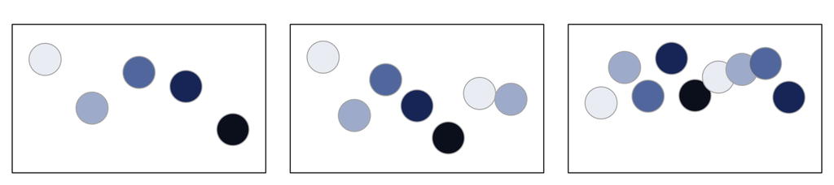

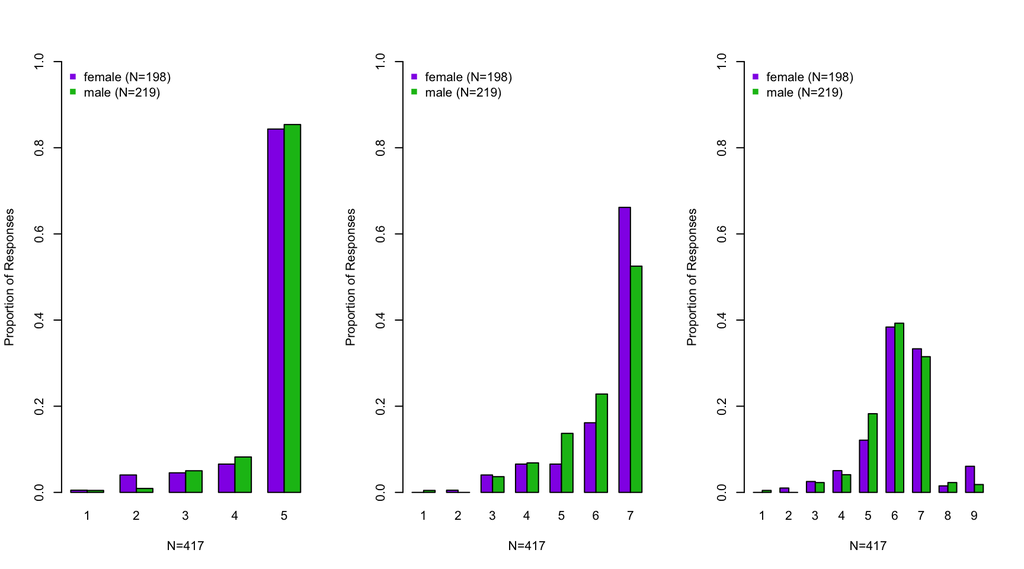

## Sex Preferences

Quiz Question: Select any palette in which all the colors included in that palette do not appear distinct to your eyes at first glance.

```r
## breakdown the data by sex
df_M <- df %>% filter(sex=="Male")
df_F <- df %>% filter(sex=="Female")

## females
length(grep("distinct", df_F$NondistinctPalette))/nrow(df_F)
```

```
## [1] 0.2474747
```

```r
## males
length(grep("distinct", df_M$NondistinctPalette))/nrow(df_M)
```

```
## [1] 0.08675799
```

```r
## how about some significance
sexdata <-
matrix(c(length(grep("distinct", df_M$NondistinctPalette)), length(grep("distinct", df_F$NondistinctPalette)), nrow(df_M)-length(grep("distinct", df_M$NondistinctPalette)), nrow(df_F)-length(grep("distinct", df_F$NondistinctPalette))),
       nrow = 2,
       dimnames =
       list(c("Males", "Females"),
            c("Distinct", "Not Distinct")))

fisher.test(sexdata,alternative="less")
```

```
##
##  Fisher's Exact Test for Count Data
##
## data:  sexdata
## p-value = 6.955e-06
## alternative hypothesis: true odds ratio is less than 1
## 95 percent confidence interval:
##  0.0000000 0.4819195
## sample estimates:
## odds ratio
##  0.2897347
```

The percentage who found all of the palletes reasonably distinct:

Females: 24.75%.

Males: 8.68%

## Plotting Preferences

For the three following plots, we asked three questions. Proportion of respones for each are plotted:

1. Check the (1) palette you think would be best for graphing.
2. Check the (1) palette you find most appropriate for graphing the boxplots below.
3. Check the (1) palette you find most appropriate for graphing the networks below.

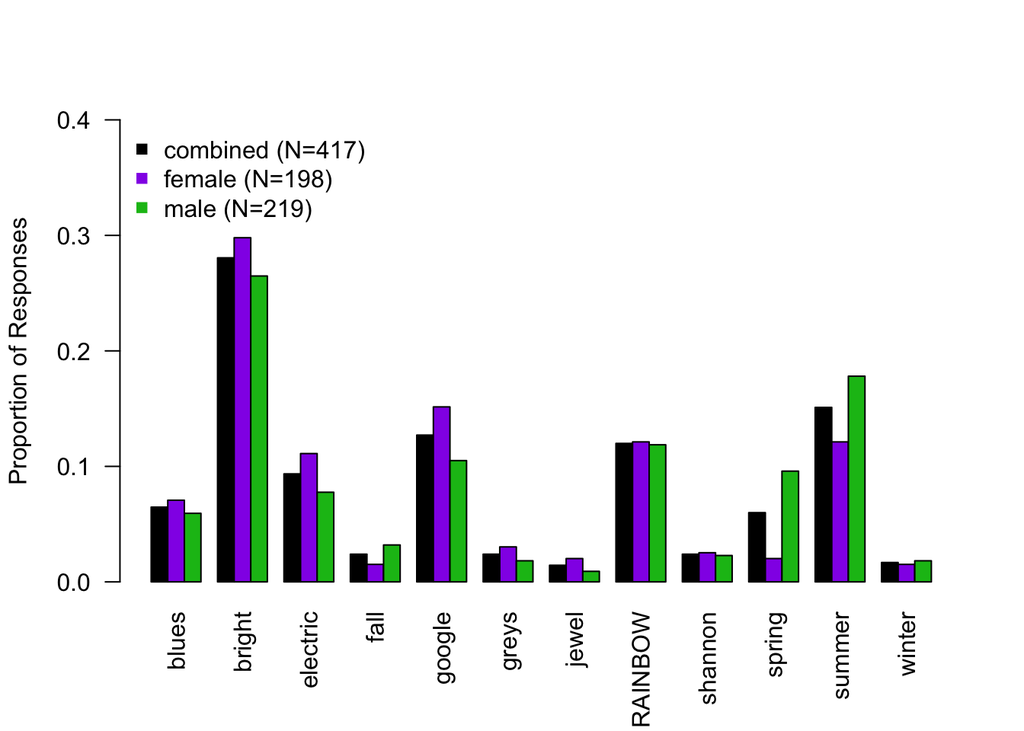

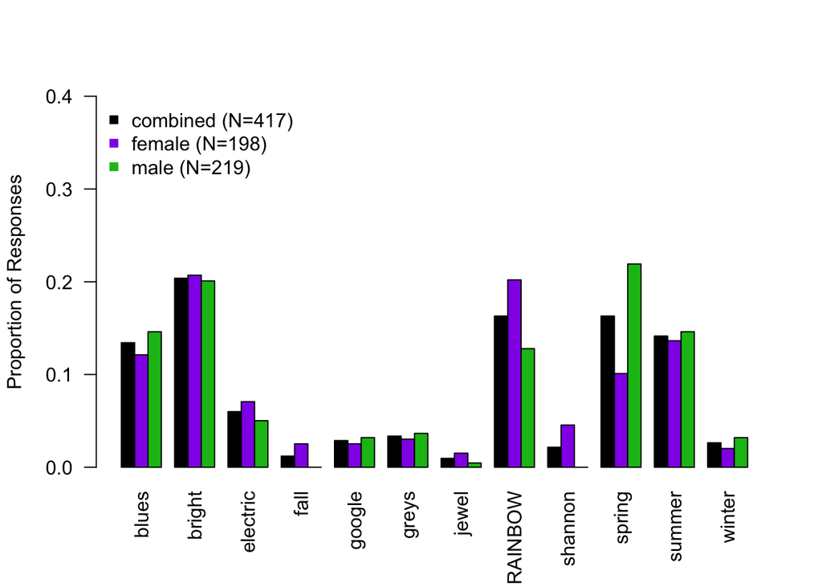

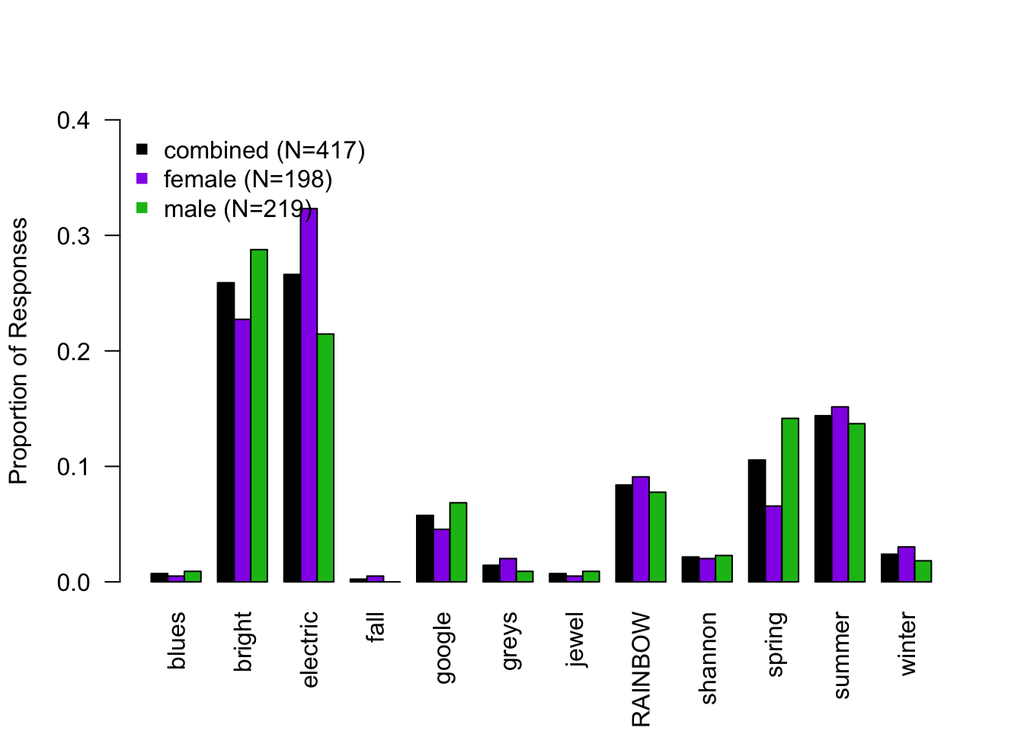